# CohortSurvival - Soluciones

Iniciación práctica al análisis de datos OMOP

Author

Affiliation

Real World Epidemiology

IDIAP Jordi Gol

### Ejercicio 1

El objetivo de esta primera actividad será estimar la supervivencia de COVID-19 en los individuos que a 1 de marzo del 2020 llevaban 180 días o más en observación en la base de datos.

##### a) Cread la cohorte que incluye la población del estudio.

```r
# Usamos el paquete IncidencePrevalence para crear la cohorte con la población del estudio
cdm <- generateDenominatorCohortSet(
  cdm = cdm,
  name = "poblacion_estudio",
  cohortDateRange = c(as.Date("2020-03-01"),
                      endDate = NA),
  daysPriorObservation = 180
)

# Miramos cómo es la tabla
cdm$poblacion_estudio %>% glimpse()
```

```
Rows: ??
Columns: 4
Database: DuckDB 1.4.4 [agiuliodori@Windows 10 x64:R 4.4.0/C:\Users\agiuliodori\AppData\Local\Temp\RtmpeqS43H\file462444ed27ba.duckdb]
$ cohort_definition_id <int> 1, 1, 1, 1, 1, 1, 1, 1, 1, 1, 1, 1, 1, 1, 1, 1, 1…
$ subject_id           <int> 1, 3, 4, 5, 6, 7, 8, 9, 10, 11, 12, 13, 14, 15, 1…
$ cohort_start_date    <date> 2020-03-01, 2020-03-01, 2020-03-01, 2020-03-01, …
$ cohort_end_date      <date> 2023-05-12, 2023-04-22, 2023-04-08, 2023-01-04, …
```

##### b) Estima la supervivencia.

```r
surv_covid <- estimateSingleEventSurvival(
  cdm = cdm,
  targetCohortTable = "poblacion_estudio",
  targetCohortId = 1,
  outcomeCohortTable = "covid",
  outcomeCohortId = 1
)
```

##### c) Haz un gráfico de los resultados

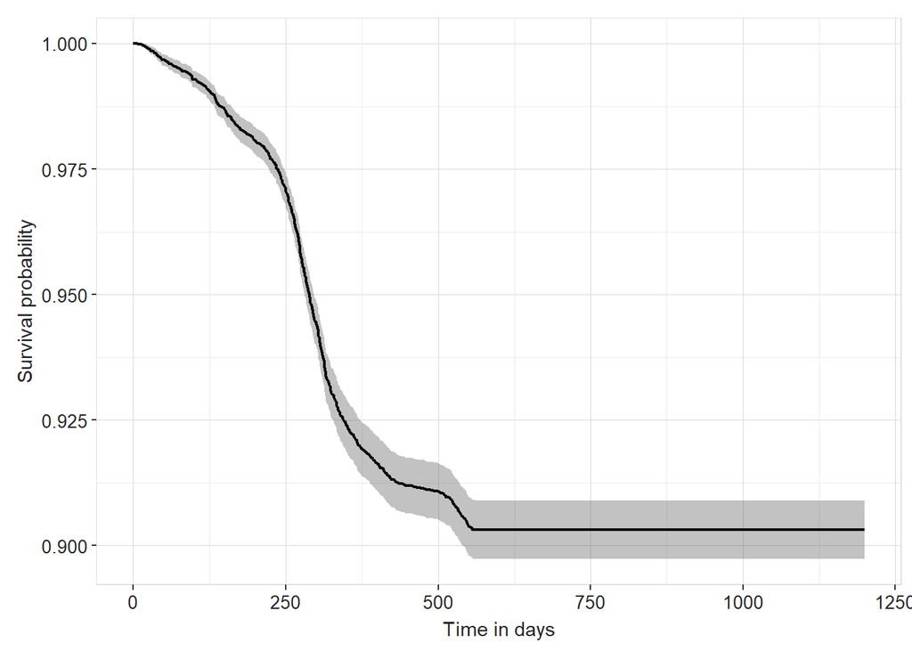

```r
plotSurvival(surv_covid)
```

### Ejercicio 2

##### a) Realiza el análisis de supervivencia anterior estratificado por sexo y representa el resultado en un gráfico.

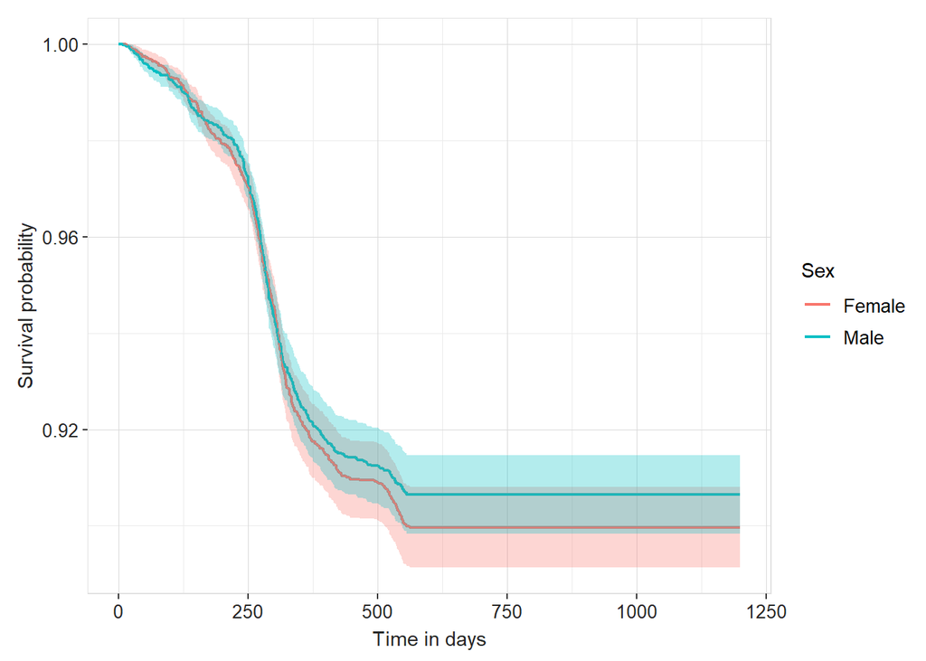

```r
cdm$poblacion_estudio <- cdm$poblacion_estudio %>%
  addSex()

surv_covid_sex <- estimateSingleEventSurvival(
  cdm = cdm,
  targetCohortTable = "poblacion_estudio",
  targetCohortId = 1,
  outcomeCohortTable = "covid",
  outcomeCohortId = 1,
  strata = list("Sexo" = "sex")
)


plotSurvival(surv_covid_sex %>%
                          dplyr::filter(strata_level != "overall"),
             colour = "sex")
```

##### b) Estratifica ahora por sexo y grupos de edad, por separado y junto, y representa el resultado en un gráfico.

Los grupos de edad son 1) menores de 65 años, y 2) personas de 65 años o más.

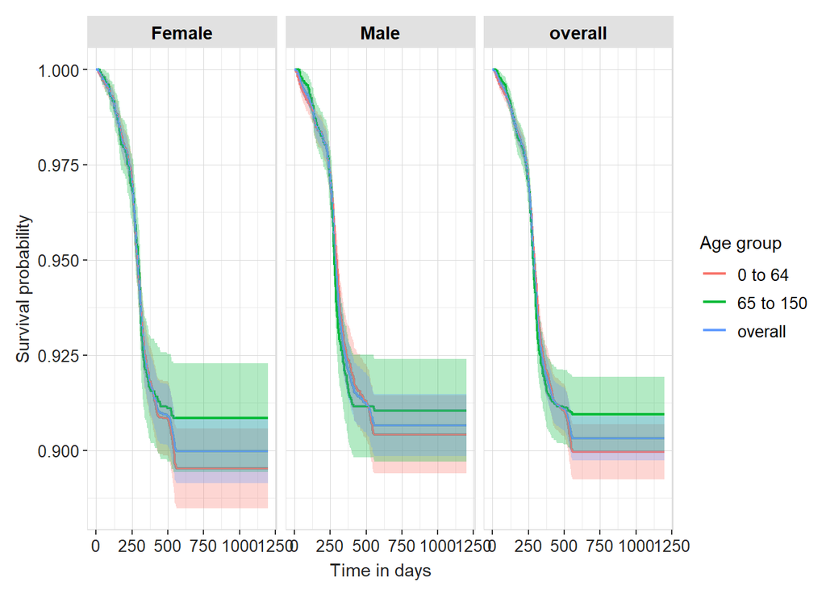

```r
cdm$poblacion_estudio <- cdm$poblacion_estudio %>%
  addAge(ageGroup = list(c(0,64), c(65,150)))

surv_covid_sex_age <- estimateSingleEventSurvival(
  cdm = cdm,
  targetCohortTable = "poblacion_estudio",
  targetCohortId = 1,
  outcomeCohortTable = "covid",
  outcomeCohortId = 1,
  strata = list("Sexo" = "sex",
                "Edad" = "age_group",
                "Edad y sexo" = c("sex", "age_group"))
)


plotSurvival(
  surv_covid_sex_age,
  facet = "sex",
  colour = "age_group"
)
```

#### c) ¿Cuál es la supervivencia de las mujeres mayores de 65 años al cabo de un mes? ¿Y de un año?

```r
#creamos la tabla de supervivencia, añadiendo los tiempos a los que queremos reportar la supervivencia

tableSurvival(surv_covid_sex_age, times = c(30, 365))
```

| CDM name | Target cohort | Sex | Age group | Outcome name | Estimate name Number records | Estimate name Number events | Estimate name Median survival (95% CI) | Estimate name Restricted mean survival (95% CI) | Estimate name 30 days survival estimate | Estimate name 365 days survival estimate |
| --- | --- | --- | --- | --- | --- | --- | --- | --- | --- | --- |
| Synthea | denominator_cohort_1 | overall | overall | covid | 10,069 | 955 | – | 1,111.00 (1,106.00, 1,117.00) | 99.85 (99.78, 99.93) | 92.11 (91.58, 92.64) |
|  |  | Female | overall | covid | 5,026 | 493 | – | 1,109.00 (1,101.00, 1,116.00) | 99.88 (99.79, 99.98) | 91.97 (91.22, 92.73) |
|  |  | Male | overall | covid | 5,043 | 462 | – | 1,114.00 (1,107.00, 1,122.00) | 99.82 (99.71, 99.94) | 92.24 (91.50, 92.99) |
|  |  | overall | 0 to 64 | covid | 6,764 | 657 | – | 1,109.00 (1,103.00, 1,116.00) | 99.79 (99.68, 99.90) | 92.25 (91.61, 92.89) |
|  |  |  | 65 to 150 | covid | 3,305 | 298 | – | 1,115.00 (1,106.00, 1,125.00) | 99.97 (99.91, 100.00) | 91.83 (90.90, 92.77) |
|  |  | Female | 0 to 64 | covid | 3,451 | 349 | – | 1,106.00 (1,096.00, 1,115.00) | – | – |
|  |  |  | 65 to 150 | covid | 1,575 | 144 | – | 1,115.00 (1,101.00, 1,128.00) | 99.94 (99.81, 100.00) | 91.80 (90.45, 93.17) |
|  |  | Male | 0 to 64 | covid | 3,313 | 308 | – | 1,113.00 (1,104.00, 1,122.00) | – | – |
|  |  |  | 65 to 150 | covid | 1,730 | 154 | – | 1,116.00 (1,103.00, 1,129.00) | 100.00 (100.00, 100.00) | 91.86 (90.57, 93.16) |
|  |  | Female | 0 to 64 | covid | – | – | – | – | 99.86 (99.73, 99.98) | 92.05 (91.15, 92.97) |
|  |  | Male | 0 to 64 | covid | – | – | – | – | 99.73 (99.55, 99.91) | 92.45 (91.55, 93.36) |

La supervivencia de las mujeres mayores de 65 años al cabo de un mes es de 99.94 y al cabo de un año de 91.80.

### Ejercicio 3

##### a) Crea la cohorte de muerte bajo el nombre “cohort_death”

```r
cdm$cohort_death <- deathCohort(
  cdm,
  name= "cohort_death",
  subsetCohort = "poblacion_estudio"
)
```

##### b) Identifica cuáles serán las cohortes *target*, *outcome*, y *competingOutcome*.

- **Target:** el nombre de la tabla es “poblacion_estudio”.
- **Outcome:** el nombre de la tabla es “covid”.
- **CompetingOutcome:** el nombre de la tabla es “cohort_death”.

*El nombre de la tabla* **target** *puede variar según cómo se haya resuelto el ejercicio.*

##### c) Estima la supervivencia, estratificando por sexo, y representa el resultado en un gráfico.

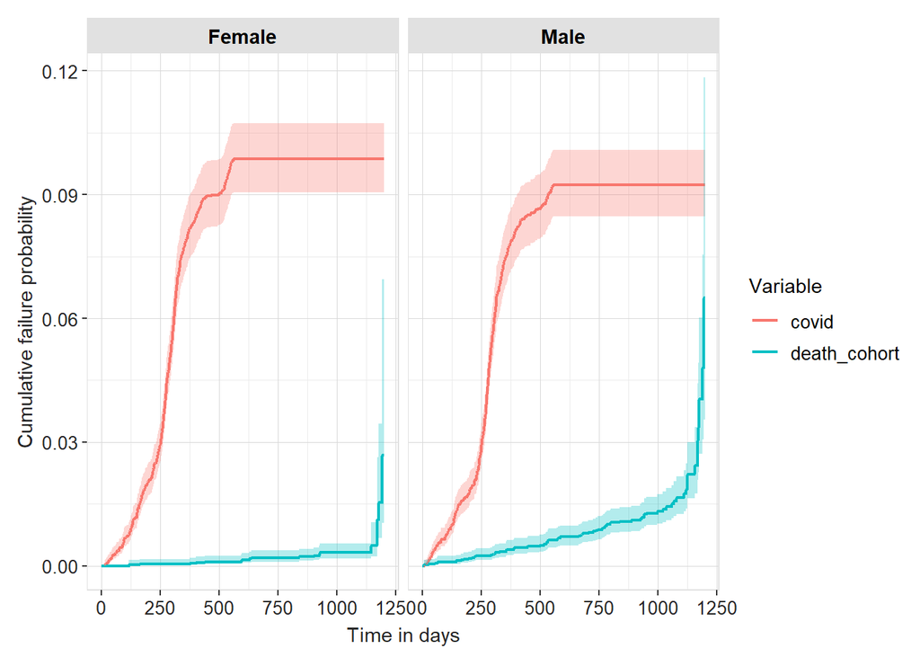

```r
comp_surv_covid_sex <- estimateCompetingRiskSurvival(
  cdm = cdm,
  targetCohortTable = "poblacion_estudio",
  targetCohortId = 1,
  outcomeCohortTable = "covid",
  outcomeCohortId = 1,
  competingOutcomeCohortTable = "cohort_death",
  competingOutcomeCohortId = 1,
  strata = list("Sexo" = "sex"),
  estimateGap = 1
)

plotSurvival((comp_surv_covid_sex%>%
                filter(strata_name!="overall")),
             cumulativeFailure = TRUE,
             colour = "variable",
             facet = "sex")
```